# Session 4: Plotting with ggplot2 + other useful packages

28 May 2019

# 1) Plotting with ggplot2

## Data

We will use the same data you used in Exercise 3 (on Friday).

```r
gapminder <- read_csv(file = "gapminder-FiveYearData.csv")
```

## Basic ggplot call

Basic components of ggplots:

1. `ggplot(data = ...)`,
2. `aes(x = ..., y = ..., color = ..., fill = ..., block = ..., shape = ..., size = ...)`,
3. graphical representation of the data [geometric objects (geoms)](http://ggplot2.tidyverse.org/reference/): `geom_point`, `geom_line`, `geom_boxplot`, `geom_hex`, …
4. the sign `+` to add layers defined at the end of the line.

Plot gdpPercap vs lifeExp.

Aesthetics defined **globally**:

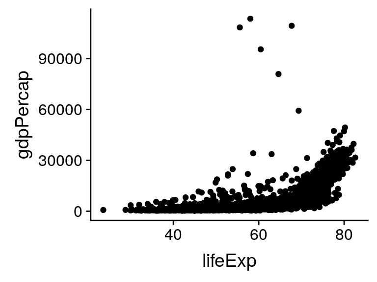

```r
library(ggplot2)

ggplot(data = gapminder, aes(x = lifeExp, y = gdpPercap)) +
  geom_point()
```

Aesthetics defined **locally**:

```r
ggplot() +
  geom_point(data = gapminder, aes(x = lifeExp, y = gdpPercap))
```

Using `aes()` within `geom_point()` gives the same result as using it within `ggplot()`.

## More about aesthetics and data mapping

Let’s change the colors, size, shape and the transparency of the points:

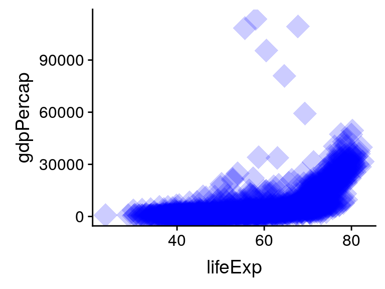

```r
ggplot(data = gapminder, aes(x = lifeExp, y = gdpPercap)) +
  geom_point(color = "blue", size = 8, shape = 18, alpha = 0.2)
```

Let’s color the points by the continent

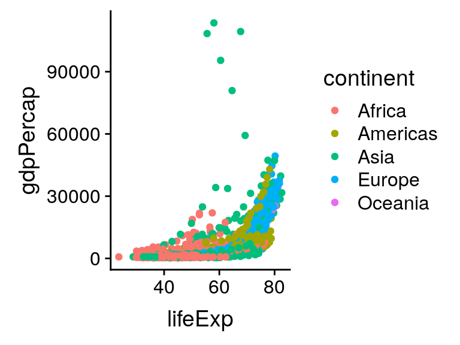

```r
#Use default colors
ggplot(data = gapminder, aes(x = lifeExp, y = gdpPercap, color = continent)) +
  geom_point()
```

```r
#Use custome colors
ggplot(data = gapminder, aes(x = lifeExp, y = gdpPercap, color = continent)) +
  geom_point() +
  scale_color_manual(values = c("orange", "blue", "green", "red", "pink"))
```

There are other `scale_` options to change the shape, size, linetype, etc. Go to [this link](http://ggplot2.tidyverse.org/reference/scale_manual.html) for ways to implement them.

Here we change the shape for each continent:

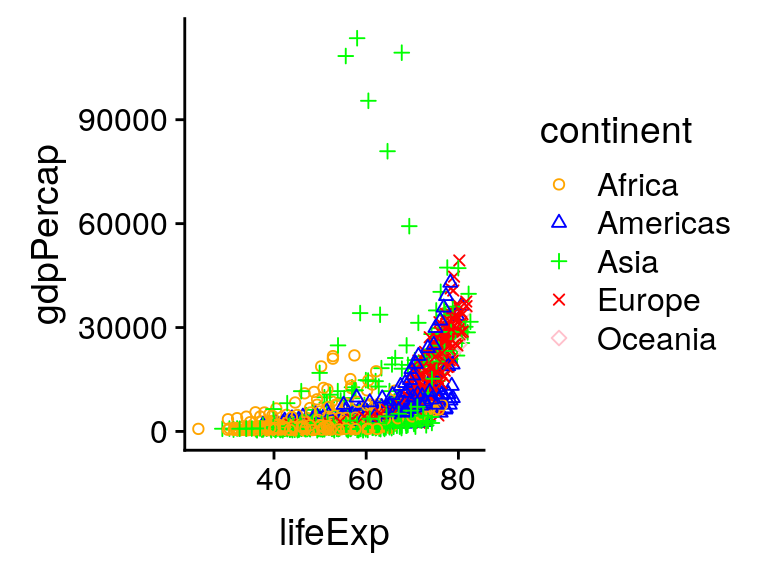

```r
ggplot(data = gapminder, aes(x = lifeExp, y = gdpPercap, color = continent, shape = continent)) +
  geom_point() +
  scale_color_manual(values = c("orange", "blue", "green", "red", "pink")) +
  scale_shape_manual(values = 1:5)
```

If we have a continuous variable like `year`, we should use a continuous gradient of colors:

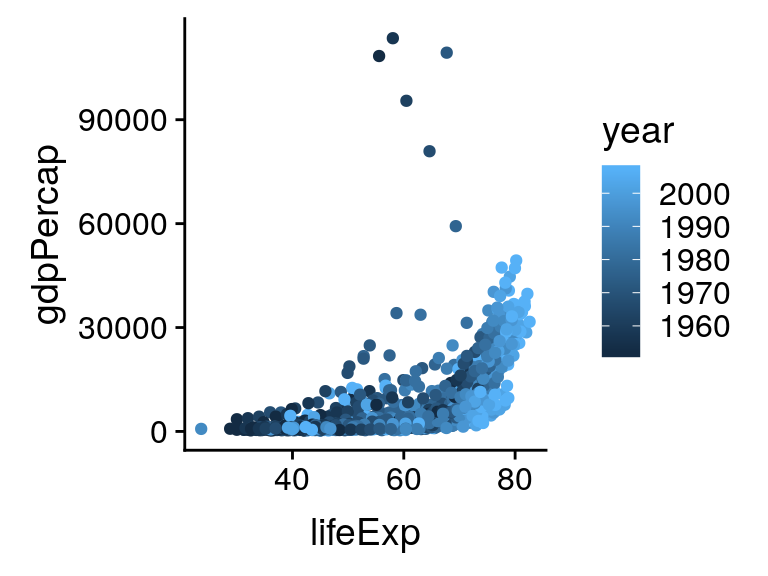

```r
ggplot(data = gapminder, aes(x = lifeExp, y = gdpPercap, color = year)) +
  geom_point()
```

We can change the color gradient by using for example, the rainbow palette `rainbow()`:

```r
ggplot(data = gapminder, aes(x = lifeExp, y = gdpPercap, color = year)) +
  geom_point() +
  scale_color_gradientn(colours = rainbow(10))
```

We use the `colorRampPalette` function to generate a continuous gradient from any set of colors

```r
library(RColorBrewer)

colors2 <- colorRampPalette(c("red", 'orange', "green", 'darkgreen'))(10)

head(colors2) #is a vector with all the color names

ggplot(data = gapminder) +
  geom_point(aes(x = lifeExp, y = gdpPercap, color = year)) +
  scale_colour_gradientn(colours = colors2)
```

Also commonly used is the `brewer.pal` function to choose a predefined set of colors. Take a look at them [here](https://moderndata.plot.ly/create-colorful-graphs-in-r-with-rcolorbrewer-and-plotly/)

```r
colors2 <- colorRampPalette(brewer.pal(n = 9, name = "YlGnBu"))(20)

ggplot(data = gapminder) +
  geom_point(aes(x = lifeExp, y = gdpPercap, color = year)) +
  scale_colour_gradientn(colours = colors2)
```

More gradient scales: http://ggplot2.tidyverse.org/reference/scale_gradient.html

## Adjusting axis range

The first two approaches (`scale_x_continuous(limits = c())`, `xlim()`) remove the data points before plotting. This may affect any visualization that uses some summary statistics, for example, boxplots.

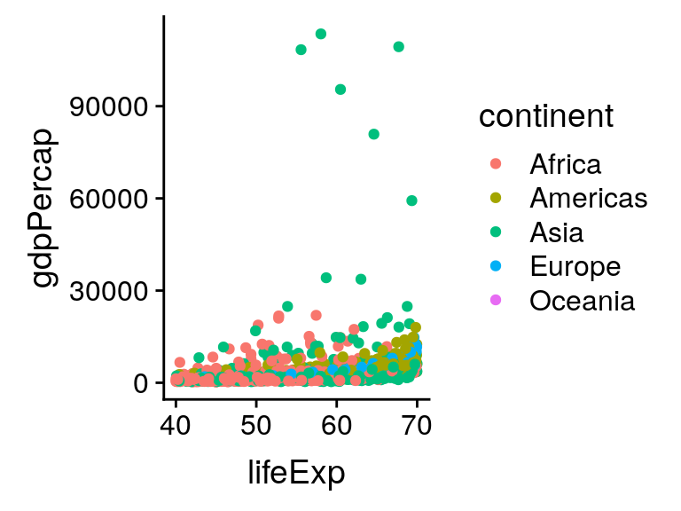

```r
ggplot(data = gapminder) +
  geom_point(aes(x = lifeExp, y = gdpPercap, color = continent)) +
  scale_x_continuous(limits = c(40, 70))
```

```r
ggplot(data = gapminder) +
  geom_point(aes(x = lifeExp, y = gdpPercap, color = continent)) +
  xlim(40, 70)
```

With this approach (`coord_cartesian(xlim = c())`), no data is removed. Only the visible area is adjusted.

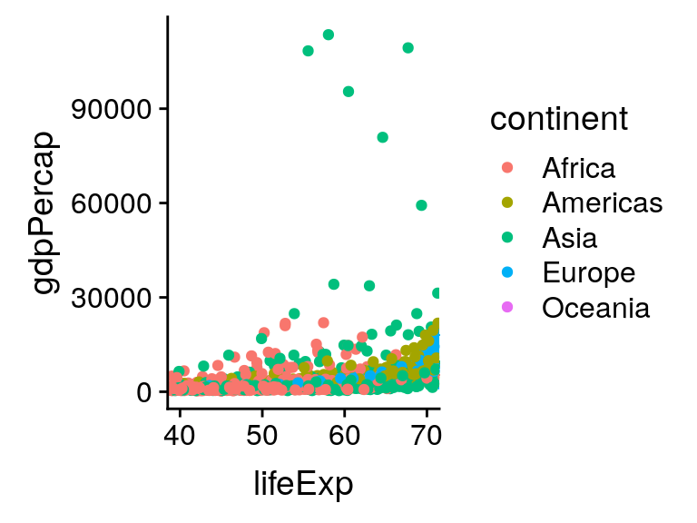

```r
ggplot(data = gapminder) +
  geom_point(aes(x = lifeExp, y = gdpPercap, color = continent)) +
  coord_cartesian(xlim = c(40, 70))
```

## Theme

The black and white theme `theme_bw()`:

```r
ggplot(data = gapminder) +
  geom_point(aes(x = lifeExp, y = gdpPercap, color = continent)) +
  theme_bw()
```

Modify components of a theme [see more here][http://ggplot2.tidyverse.org/reference/theme.html]

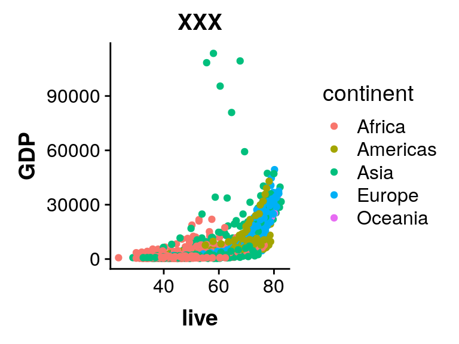

```r
ggplot(data = gapminder) +
  geom_point(aes(x = lifeExp, y = gdpPercap, color = continent)) +
  ggtitle("XXX") +
  xlab("live") +
  ylab("GDP") +
  theme(axis.title = element_text(face = "bold"))
```

## Faceting

Let’s stratify the plot by continent with `facet_wrap()`:

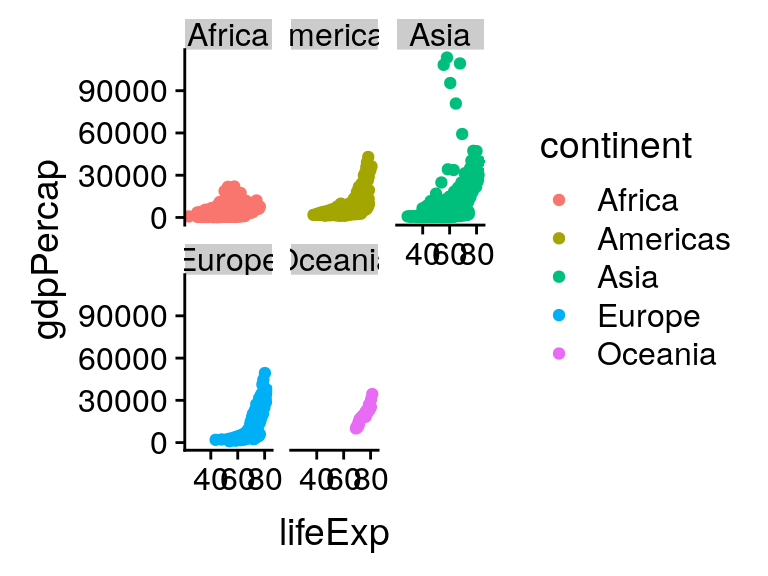

```r
ggplot(data = gapminder) +
  geom_point(aes(x = lifeExp, y = gdpPercap, color = continent)) +
  facet_wrap(~ continent)
```

See also `facet_grid()` here

## Other geoms

See http://ggplot2.tidyverse.org/reference/

### Histogram

Rather for continuous data.

Histogram of lifeExp:

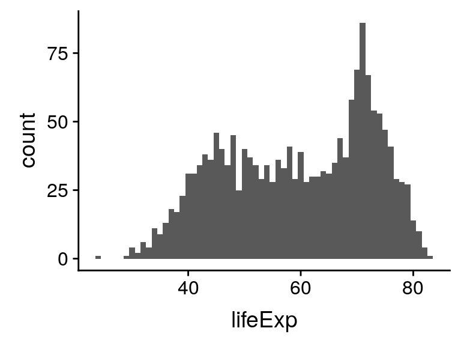

```r
ggplot(data = gapminder, aes(x = lifeExp)) +
  geom_histogram(binwidth = 1)
```

Colored by continent:

```r
ggplot(data = gapminder, aes(x = lifeExp, fill = continent)) + #use fill instead of color
  geom_histogram(binwidth = 1)
```

### Density

Distribution of lifeExp represented with density:

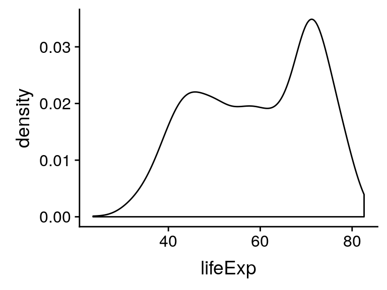

```r
ggplot(data = gapminder, aes(x = lifeExp)) +
  geom_density()
```

Plot a line per country and color by continent:

```r
ggplot(data = gapminder, aes(x = lifeExp, color = continent, block = country)) +
  geom_density()
```

### Barplot

Rather for discrete data.

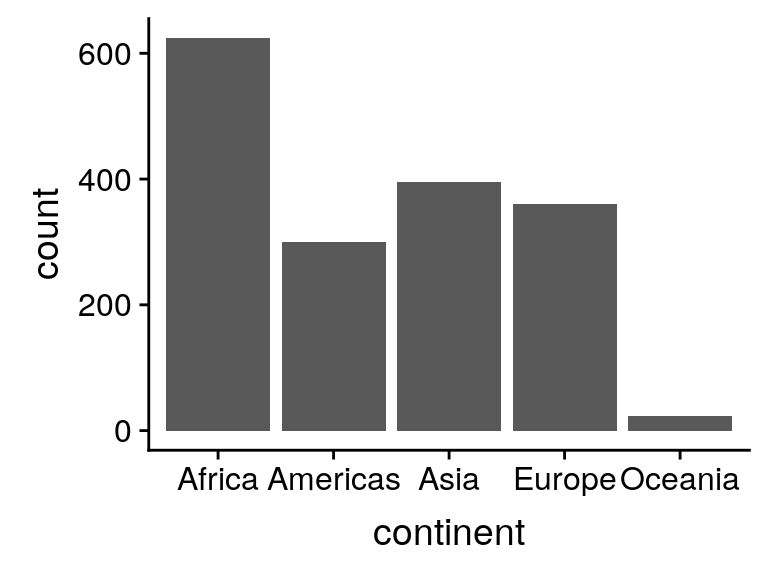

```r
ggplot(data = gapminder, aes(x = continent)) +
  geom_bar()
```

### Violin plot + boxplot + jitter

We can plot multiple layers in one figure.

Let’s represent the distributions of gdpPercap for each continent:

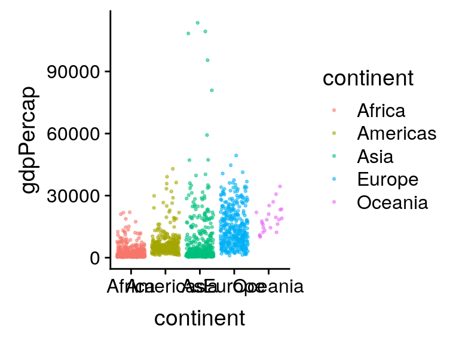

```r
ggplot(data = gapminder, aes(x = continent, y = gdpPercap, color = continent)) +
  geom_jitter(size = 0.5, alpha = 0.5)
```

```r
  #geom_boxplot(outlier.color = NA) +
  #geom_violin(scale = "width")
```

## Saving figures

Using `pdf()`, `png()`, `bmp()`, `tiff()`, or `jpeg()` and `dev.off()`:

```r
pdf("hist1.pdf")
ggplot(data = gapminder, aes(x = gdpPercap)) +
  geom_histogram(bins = 50)
dev.off()
```

Using `ggsave()`:

```r
ggplot(data = gapminder, aes(x = gdpPercap)) +
  geom_histogram(bins = 50)

ggsave("hist3.pdf")
#ggsave("hist3.png")
```

Note that you can change the extension file in `ggsave` for any other image format (e.g. jpg, png, tiff), just by changing the file name.

## Multipanel figures with cowplot

See [Introduction to cowplot](https://cran.r-project.org/web/packages/cowplot/vignettes/introduction.html).

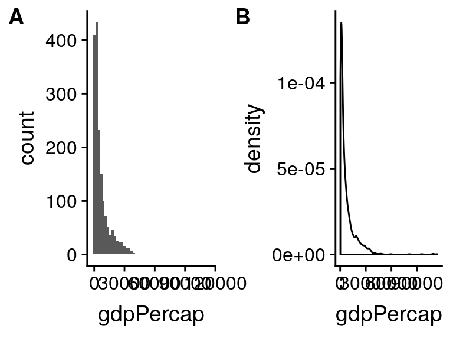

```r
library(cowplot)

ggp1 <- ggplot(data = gapminder, aes(x = gdpPercap)) +
  geom_histogram(bins = 50)

ggp2 <- ggplot(data = gapminder, aes(x = gdpPercap)) +
  geom_density()

plot_grid(ggp1, ggp2, labels = c("A", "B"))
```

# 2) Heatmap

## Colors & names

Let’s start by visualizing a simple matrix:

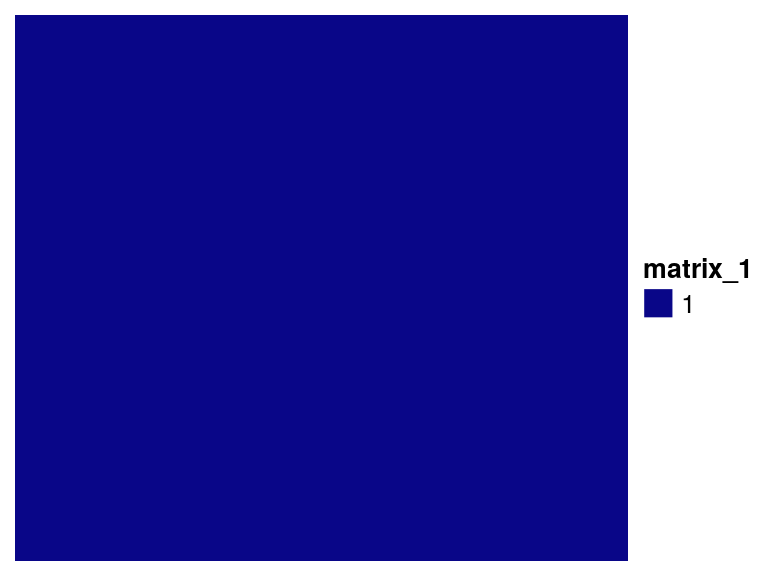

```r
mat <- matrix(1, nrow = 20, ncol = 10)
Heatmap(mat)
```

We change the legend using `name`.

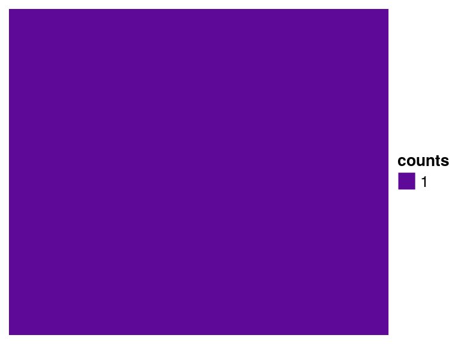

```r
Heatmap(mat, name = "counts")
```

And the color using `col`.

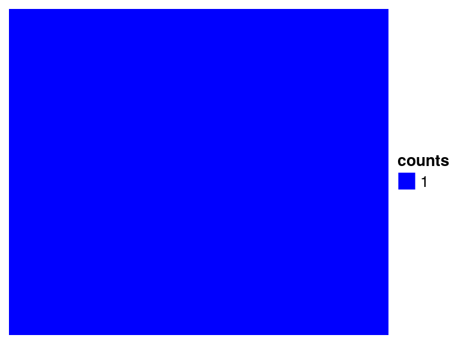

```r
Heatmap(mat, name = "counts", col = "blue")
```

Each entry value can be visualized separately as a rectangular grid

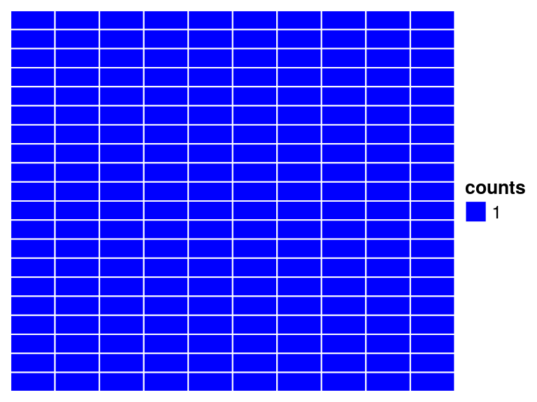

```r
Heatmap(mat,rect_gp = gpar(col = "white"),
        name = "counts", col = "blue")
```

Let’s name the matrix and add values to some entries of the matrix.

```r
# name
colnames(mat) <- paste0("sample", 1:ncol(mat))
rownames(mat) <- paste0("gene", 1:nrow(mat))
mat
```

```
##        sample1 sample2 sample3 sample4 sample5 sample6 sample7 sample8
## gene1        1       1       1       1       1       1       1       1
## gene2        1       1       1       1       1       1       1       1
## gene3        1       1       1       1       1       1       1       1
## gene4        1       1       1       1       1       1       1       1
## gene5        1       1       1       1       1       1       1       1
## gene6        1       1       1       1       1       1       1       1
## gene7        1       1       1       1       1       1       1       1
## gene8        1       1       1       1       1       1       1       1
## gene9        1       1       1       1       1       1       1       1
## gene10       1       1       1       1       1       1       1       1
## gene11       1       1       1       1       1       1       1       1
## gene12       1       1       1       1       1       1       1       1
## gene13       1       1       1       1       1       1       1       1
## gene14       1       1       1       1       1       1       1       1
## gene15       1       1       1       1       1       1       1       1
## gene16       1       1       1       1       1       1       1       1
## gene17       1       1       1       1       1       1       1       1
## gene18       1       1       1       1       1       1       1       1
## gene19       1       1       1       1       1       1       1       1
## gene20       1       1       1       1       1       1       1       1
##        sample9 sample10
## gene1        1        1
## gene2        1        1
## gene3        1        1
## gene4        1        1
## gene5        1        1
## gene6        1        1
## gene7        1        1
## gene8        1        1
## gene9        1        1
## gene10       1        1
## gene11       1        1
## gene12       1        1
## gene13       1        1
## gene14       1        1
## gene15       1        1
## gene16       1        1
## gene17       1        1
## gene18       1        1
## gene19       1        1
## gene20       1        1
```

```r
# change some entries
set.seed(1)
ri <- sample(1:nrow(mat), 5)
mat[ri, 1:5] <- mat[ri, 1:5] + 1
mat
```

```
##        sample1 sample2 sample3 sample4 sample5 sample6 sample7 sample8
## gene1        2       2       2       2       2       1       1       1
## gene2        2       2       2       2       2       1       1       1
## gene3        1       1       1       1       1       1       1       1
## gene4        2       2       2       2       2       1       1       1
## gene5        1       1       1       1       1       1       1       1
## gene6        1       1       1       1       1       1       1       1
## gene7        2       2       2       2       2       1       1       1
## gene8        1       1       1       1       1       1       1       1
## gene9        1       1       1       1       1       1       1       1
## gene10       1       1       1       1       1       1       1       1
## gene11       1       1       1       1       1       1       1       1
## gene12       1       1       1       1       1       1       1       1
## gene13       2       2       2       2       2       1       1       1
## gene14       1       1       1       1       1       1       1       1
## gene15       1       1       1       1       1       1       1       1
## gene16       1       1       1       1       1       1       1       1
## gene17       1       1       1       1       1       1       1       1
## gene18       1       1       1       1       1       1       1       1
## gene19       1       1       1       1       1       1       1       1
## gene20       1       1       1       1       1       1       1       1
##        sample9 sample10
## gene1        1        1
## gene2        1        1
## gene3        1        1
## gene4        1        1
## gene5        1        1
## gene6        1        1
## gene7        1        1
## gene8        1        1
## gene9        1        1
## gene10       1        1
## gene11       1        1
## gene12       1        1
## gene13       1        1
## gene14       1        1
## gene15       1        1
## gene16       1        1
## gene17       1        1
## gene18       1        1
## gene19       1        1
## gene20       1        1
```

## Clustering & Labels

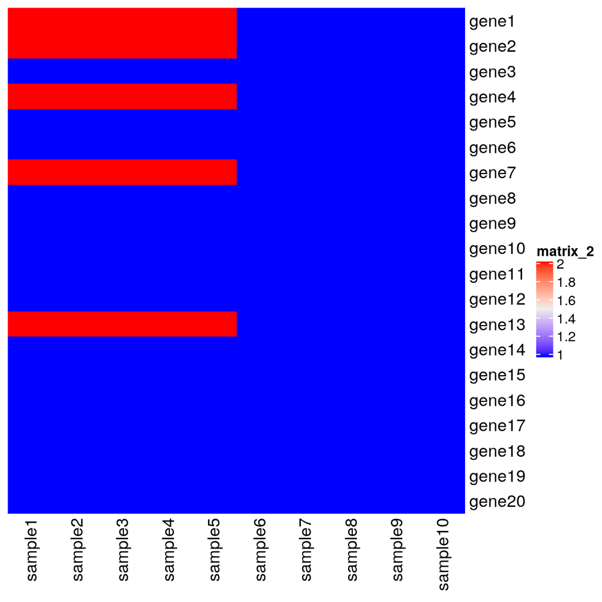

```r
Heatmap(mat, cluster_rows = FALSE, cluster_columns = FALSE)
```

Let’s move the row labels to the left.

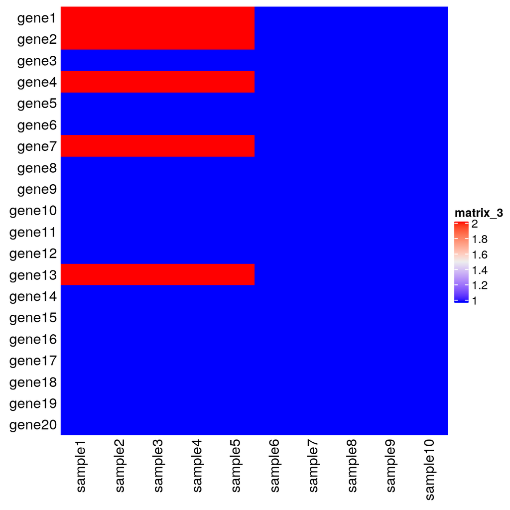

```r
Heatmap(mat, cluster_rows = FALSE, cluster_columns = FALSE,
        row_names_side = "left")
```

If we prefer to show genes with the same pattern together, we could cluster the rows

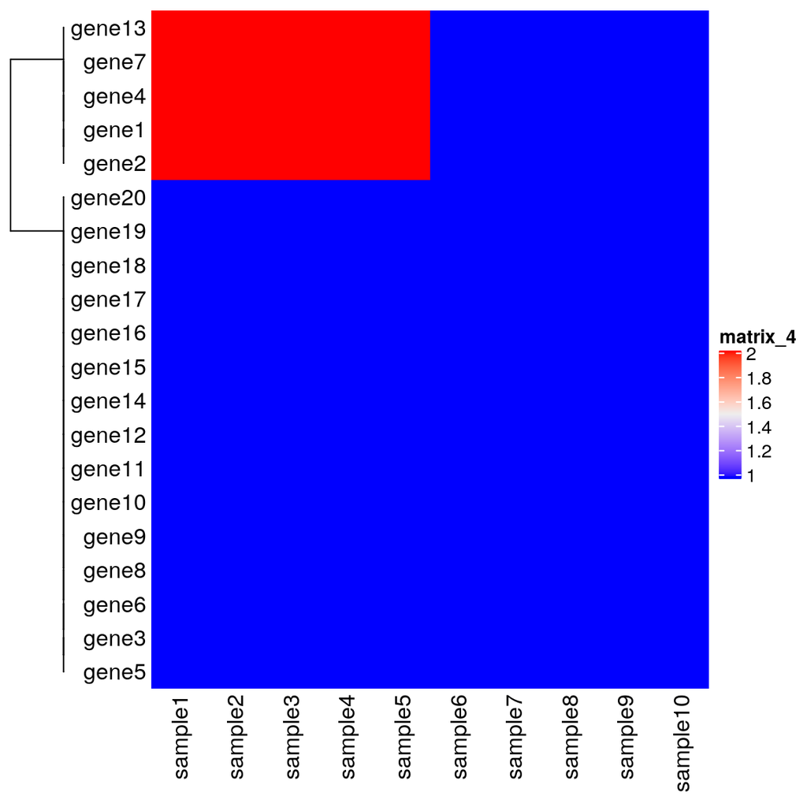

```r
Heatmap(mat, cluster_rows = TRUE, cluster_columns = FALSE,
        row_names_side = "left")
```

```r
ri
```

```
## [1]  4  7  1  2 13
```

## Annotation

We label the samples by adding annotation to the columns of the heatmap.

```r
sampAnno <- rep(c("Treated", "Control"), each = 5)
names(sampAnno) <- colnames(mat)
sampAnno
```

```
##   sample1   sample2   sample3   sample4   sample5   sample6   sample7
## "Treated" "Treated" "Treated" "Treated" "Treated" "Control" "Control"
##   sample8   sample9  sample10
## "Control" "Control" "Control"
```

[figure not shown]

```r
ha1 <- HeatmapAnnotation(group = sampAnno)
draw(ha1)
```

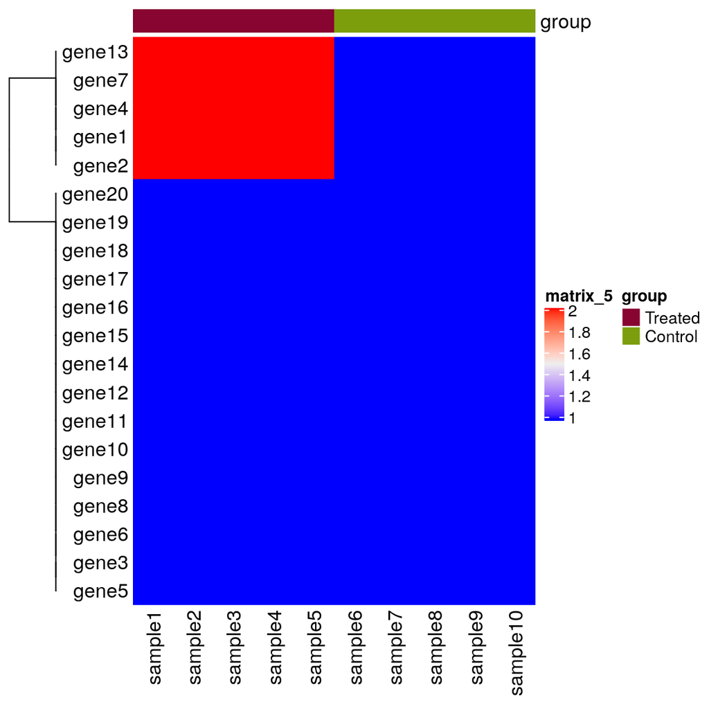

```r
Heatmap(mat, top_annotation = ha1,
        cluster_rows = TRUE, cluster_columns = FALSE,
        row_names_side = "left")
```

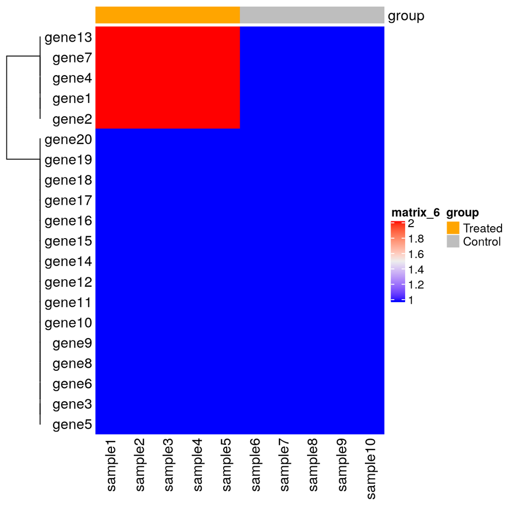

```r
ha2 <- HeatmapAnnotation(group = sampAnno,
                        col = list(group = c("Treated" = "orange", "Control" = "grey")))
Heatmap(mat, top_annotation = ha2,
        cluster_rows = TRUE, cluster_columns = FALSE,
        row_names_side = "left")
```

Let’s make the matrix have more dynamic values by adding errors simulated from a normal distribution.

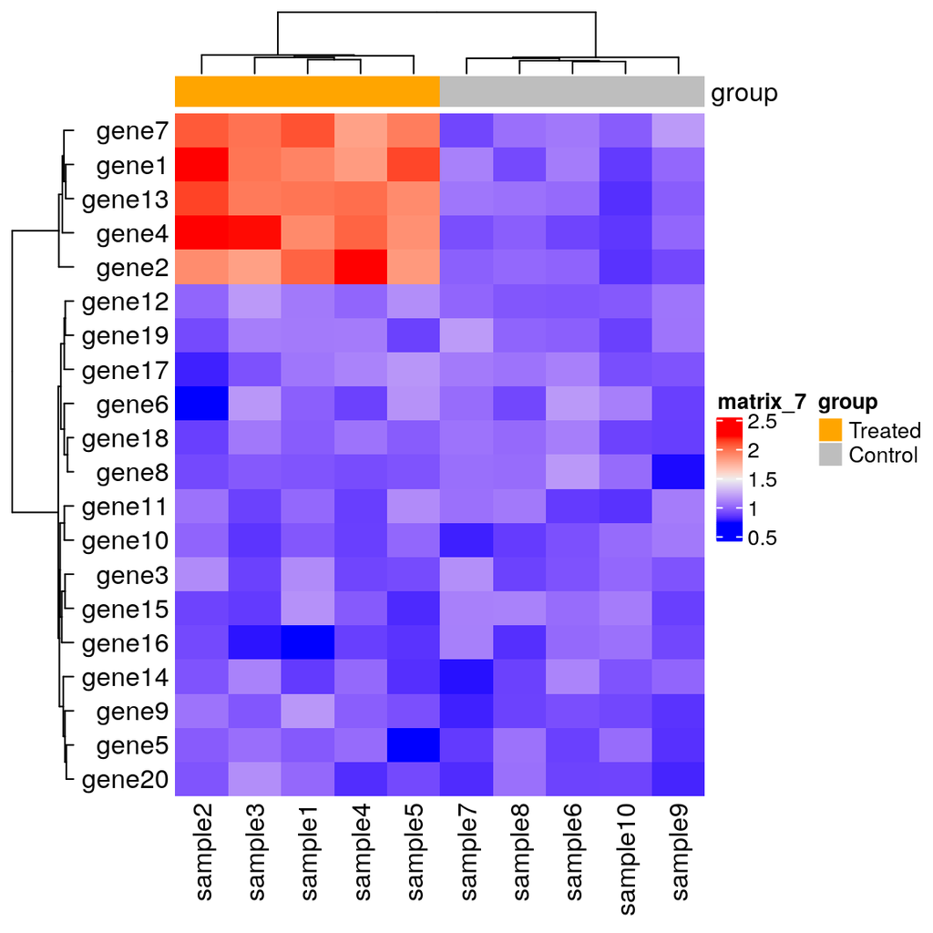

```r
set.seed(2)
matU <- mat + matrix(rnorm(n = 200, mean = 0, sd = 0.1), nrow = 20)
Heatmap(matU, top_annotation = ha2,
        cluster_rows = TRUE, cluster_columns = TRUE,
        row_names_side = "left")
```

A boxplot in the right part of the figure to show the expression level of each gene.

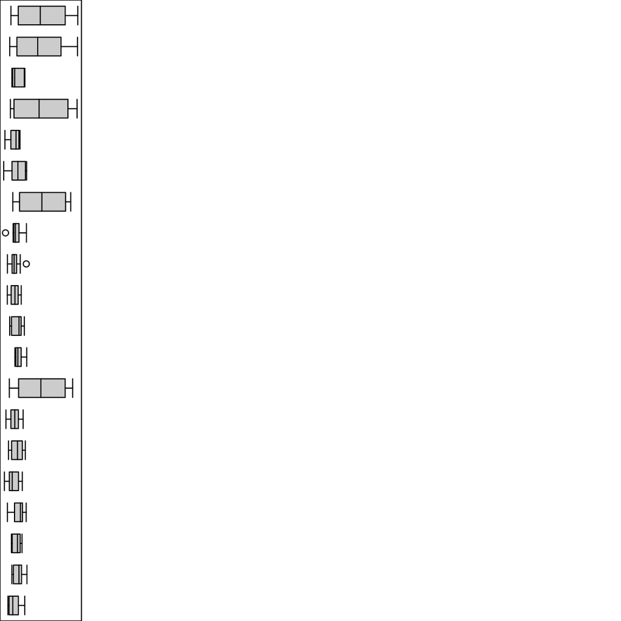

```r
ha3 <- rowAnnotation(expLevel = anno_boxplot(matU))
draw(ha3)
```

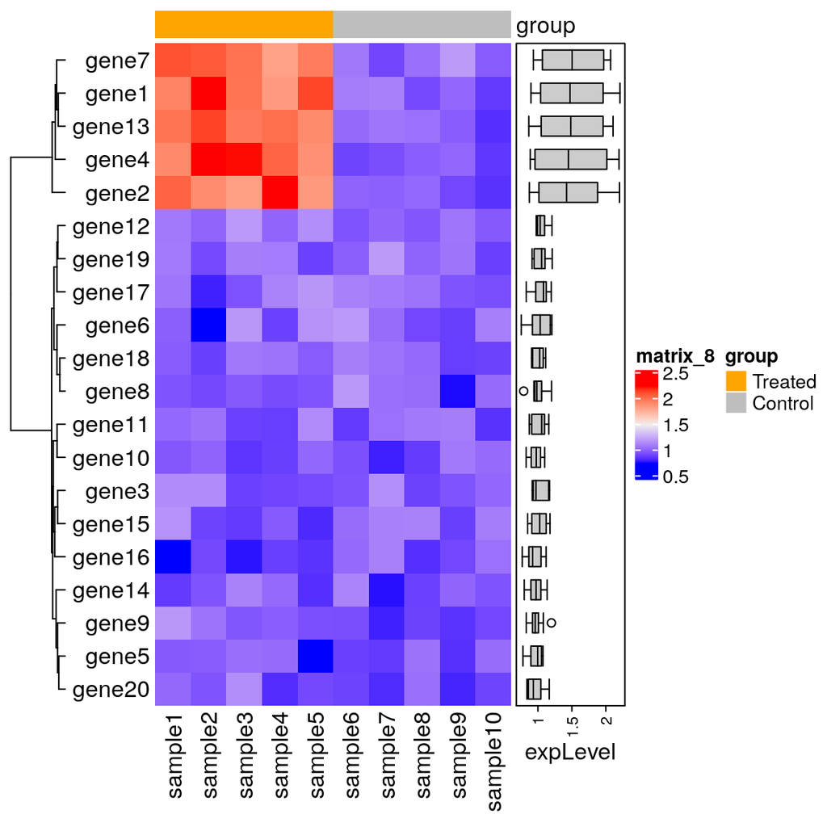

```r
Heatmap(matU, right_annotation = ha3,
        top_annotation = ha2,
        cluster_rows = TRUE, cluster_columns = FALSE,
        row_names_side = "left")
```

We might want to compare the expression level of genes between groups. To do this, we draw a scatter plot. The groups are labelled with colors.

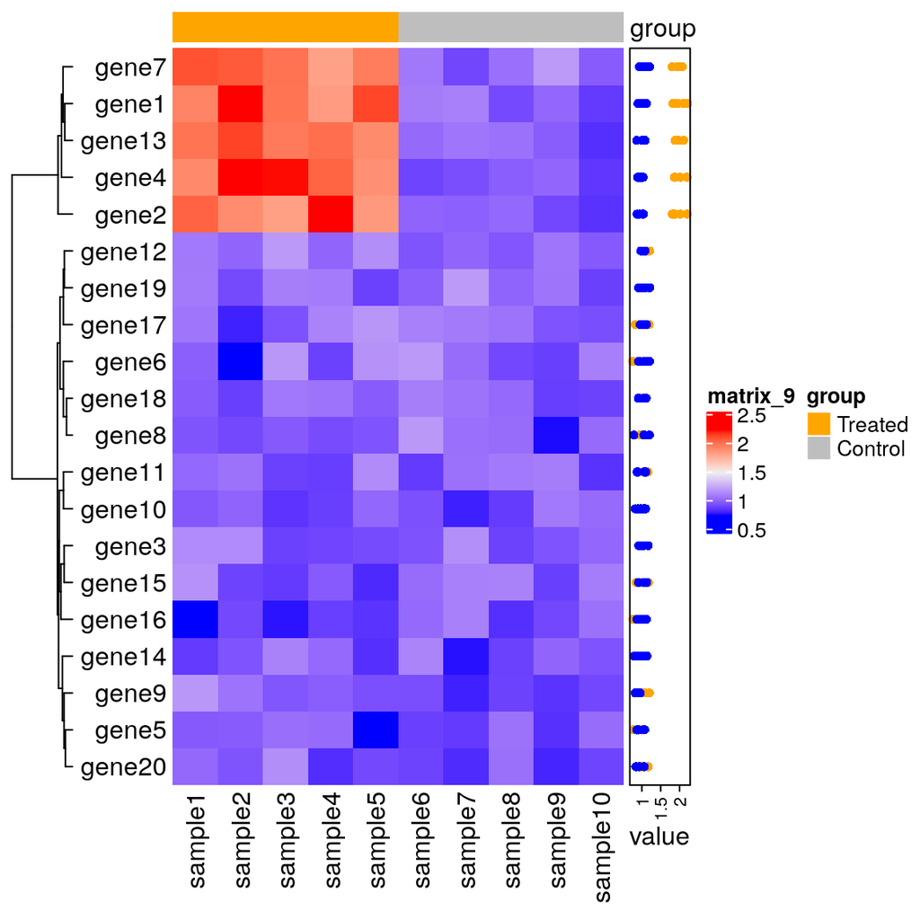

```r
# mm <- t(apply(matU, 1, function(x) {x/sum(x)}))
# mm <- cbind(rowSums(mm[, 1:5]), rowSums(mm[, 6:10]))
# ha4 <- rowAnnotation(expLevel = anno_barplot(mm,
#                      gp = gpar(fill = 2:3, color = 2:3)))
ha4 <- rowAnnotation(value = anno_points(matU,
                                         gp = gpar(col = rep(c("orange", "blue"), each = 5))))
Heatmap(matU, right_annotation = ha4,
        top_annotation = ha2,
        cluster_rows = TRUE, cluster_columns = FALSE,
        row_names_side = "left")
```

## Legend & Titles

To add legend for the scatter plot, we can do it as below.

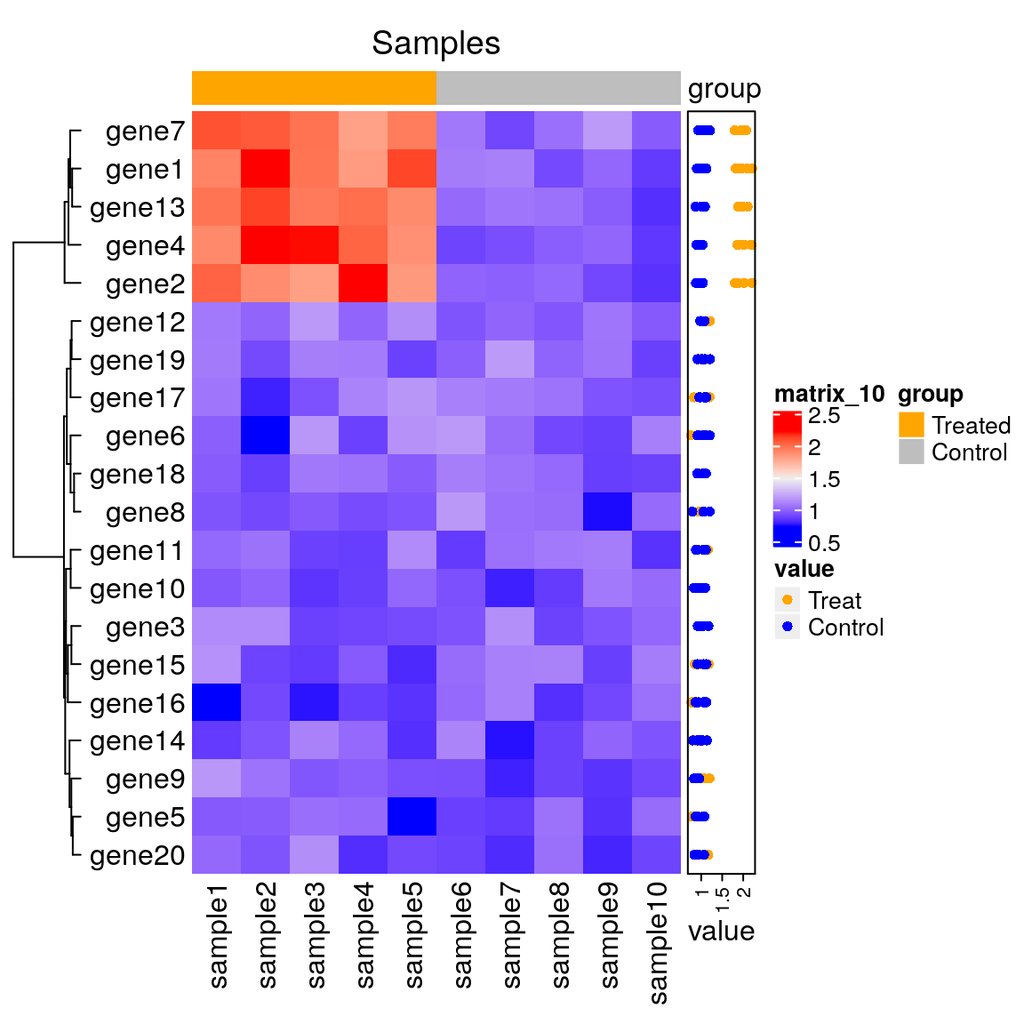

```r
lg_point = Legend(labels = c("Treat", "Control"), title = "value",
                  type = "points",
                  legend_gp = gpar(fill = c("orange", "blue"),
                                   col = c("orange", "blue")))
p <- Heatmap(matU, right_annotation = ha4,
        top_annotation = ha2,
        cluster_rows = TRUE, cluster_columns = FALSE,
        row_names_side = "left",
        column_title = "Samples")
draw(p, heatmap_legend_list = list(lg_point))
```

## Multiple heatmaps

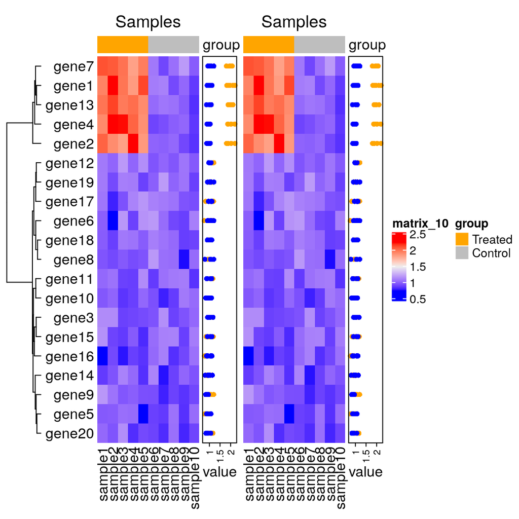

```r
p + p
```